# loblaws

```python
import pandas as pd
import numpy as np
from scipy.stats import chi2_contingency, pointbiserialr

from sklearn.preprocessing import LabelEncoder
from scipy.stats import chi2_contingency, pointbiserialr
from sklearn.model_selection import train_test_split
from sklearn.preprocessing import StandardScaler
from sklearn.pipeline import Pipeline
from sklearn.ensemble import RandomForestClassifier
from sklearn.metrics import classification_report, confusion_matrix
```

```python
import warnings
warnings.filterwarnings('ignore')
```

```python
# Load the data
file_path = 'loblaws.csv'
data = pd.read_csv(file_path)

# Display the first few rows of the dataset
data.head()
```

|  | CustomerID | Churn | Tenure | PreferredLoginDevice | CityTier | WarehouseToHome | PreferredPaymentMode | Gender | HourSpendOnApp | NumberOfDeviceRegistered | PreferedOrderCat | SatisfactionScore | MaritalStatus | NumberOfAddress | Complain | OrderAmountHikeFromlastYear | CouponUsed | OrderCount | DaySinceLastOrder | CashbackAmount |
| --- | --- | --- | --- | --- | --- | --- | --- | --- | --- | --- | --- | --- | --- | --- | --- | --- | --- | --- | --- | --- |
| 0 | 50001 | 1 | 4.0 | Mobile Phone | 3 | 6.0 | Debit Card | Female | 3.0 | 3 | Laptop & Accessory | 2 | Single | 9 | 1 | 11.0 | 1.0 | 1.0 | 5.0 | 160 |
| 1 | 50002 | 1 | NaN | Phone | 1 | 8.0 | UPI | Male | 3.0 | 4 | Mobile | 3 | Single | 7 | 1 | 15.0 | 0.0 | 1.0 | 0.0 | 121 |
| 2 | 50003 | 1 | NaN | Phone | 1 | 30.0 | Debit Card | Male | 2.0 | 4 | Mobile | 3 | Single | 6 | 1 | 14.0 | 0.0 | 1.0 | 3.0 | 120 |
| 3 | 50004 | 1 | 0.0 | Phone | 3 | 15.0 | Debit Card | Male | 2.0 | 4 | Laptop & Accessory | 5 | Single | 8 | 0 | 23.0 | 0.0 | 1.0 | 3.0 | 134 |
| 4 | 50005 | 1 | 0.0 | Phone | 1 | 12.0 | CC | Male | NaN | 3 | Mobile | 5 | Single | 3 | 0 | 11.0 | 1.0 | 1.0 | 3.0 | 130 |

```python
# Summary statistics
data.describe(include='all')
```

|  | CustomerID | Churn | Tenure | PreferredLoginDevice | CityTier | WarehouseToHome | PreferredPaymentMode | Gender | HourSpendOnApp | NumberOfDeviceRegistered | PreferedOrderCat | SatisfactionScore | MaritalStatus | NumberOfAddress | Complain | OrderAmountHikeFromlastYear | CouponUsed | OrderCount | DaySinceLastOrder | CashbackAmount |
| --- | --- | --- | --- | --- | --- | --- | --- | --- | --- | --- | --- | --- | --- | --- | --- | --- | --- | --- | --- | --- |
| count | 5630.000000 | 5630.000000 | 5366.000000 | 5630 | 5630.000000 | 5379.000000 | 5630 | 5630 | 5375.000000 | 5630.000000 | 5630 | 5630.000000 | 5630 | 5630.000000 | 5630.000000 | 5365.000000 | 5374.000000 | 5372.000000 | 5323.000000 | 5630.000000 |
| unique | NaN | NaN | NaN | 3 | NaN | NaN | 7 | 2 | NaN | NaN | 6 | NaN | 3 | NaN | NaN | NaN | NaN | NaN | NaN | NaN |
| top | NaN | NaN | NaN | Mobile Phone | NaN | NaN | Debit Card | Male | NaN | NaN | Laptop & Accessory | NaN | Married | NaN | NaN | NaN | NaN | NaN | NaN | NaN |
| freq | NaN | NaN | NaN | 2765 | NaN | NaN | 2314 | 3384 | NaN | NaN | 2050 | NaN | 2986 | NaN | NaN | NaN | NaN | NaN | NaN | NaN |
| mean | 52815.500000 | 0.168384 | 10.189899 | NaN | 1.654707 | 15.639896 | NaN | NaN | 2.931535 | 3.688988 | NaN | 3.066785 | NaN | 4.214032 | 0.284902 | 15.707922 | 1.751023 | 3.008004 | 4.543491 | 177.221492 |
| std | 1625.385339 | 0.374240 | 8.557241 | NaN | 0.915389 | 8.531475 | NaN | NaN | 0.721926 | 1.023999 | NaN | 1.380194 | NaN | 2.583586 | 0.451408 | 3.675485 | 1.894621 | 2.939680 | 3.654433 | 49.193869 |
| min | 50001.000000 | 0.000000 | 0.000000 | NaN | 1.000000 | 5.000000 | NaN | NaN | 0.000000 | 1.000000 | NaN | 1.000000 | NaN | 1.000000 | 0.000000 | 11.000000 | 0.000000 | 1.000000 | 0.000000 | 0.000000 |
| 25% | 51408.250000 | 0.000000 | 2.000000 | NaN | 1.000000 | 9.000000 | NaN | NaN | 2.000000 | 3.000000 | NaN | 2.000000 | NaN | 2.000000 | 0.000000 | 13.000000 | 1.000000 | 1.000000 | 2.000000 | 146.000000 |
| 50% | 52815.500000 | 0.000000 | 9.000000 | NaN | 1.000000 | 14.000000 | NaN | NaN | 3.000000 | 4.000000 | NaN | 3.000000 | NaN | 3.000000 | 0.000000 | 15.000000 | 1.000000 | 2.000000 | 3.000000 | 163.000000 |
| 75% | 54222.750000 | 0.000000 | 16.000000 | NaN | 3.000000 | 20.000000 | NaN | NaN | 3.000000 | 4.000000 | NaN | 4.000000 | NaN | 6.000000 | 1.000000 | 18.000000 | 2.000000 | 3.000000 | 7.000000 | 196.000000 |
| max | 55630.000000 | 1.000000 | 61.000000 | NaN | 3.000000 | 127.000000 | NaN | NaN | 5.000000 | 6.000000 | NaN | 5.000000 | NaN | 22.000000 | 1.000000 | 26.000000 | 16.000000 | 16.000000 | 46.000000 | 325.000000 |

```python
# Check for missing values
data.isnull().sum()
```

```
CustomerID                       0
Churn                            0
Tenure                         264
PreferredLoginDevice             0
CityTier                         0
WarehouseToHome                251
PreferredPaymentMode             0
Gender                           0
HourSpendOnApp                 255
NumberOfDeviceRegistered         0
PreferedOrderCat                 0
SatisfactionScore                0
MaritalStatus                    0
NumberOfAddress                  0
Complain                         0
OrderAmountHikeFromlastYear    265
CouponUsed                     256
OrderCount                     258
DaySinceLastOrder              307
CashbackAmount                   0
dtype: int64
```

```python
# Fill missing numerical values with the median
num_cols_with_missing = ['Tenure', 'WarehouseToHome', 'HourSpendOnApp',
                         'OrderAmountHikeFromlastYear', 'CouponUsed', 'OrderCount', 'DaySinceLastOrder']

for col in num_cols_with_missing:
    data[col].fillna(data[col].median(), inplace=True)
```

```python
# Encode categorical variables
label_encoders = {}
categorical_columns = ['PreferredLoginDevice', 'PreferredPaymentMode', 'Gender', 'PreferedOrderCat', 'MaritalStatus']
```

```python
for column in categorical_columns:
    le = LabelEncoder()
    data[column] = le.fit_transform(data[column])
    label_encoders[column] = le
```

```python
# Function to compute point-biserial correlation
def compute_point_biserial_correlation(dataframe, binary_col, continuous_col):
    return pointbiserialr(dataframe[binary_col], dataframe[continuous_col])[0]

# Function to compute chi-squared test for association
def compute_chi_squared_association(dataframe, binary_col, categorical_col):
    contingency_table = pd.crosstab(dataframe[binary_col], dataframe[categorical_col])
    chi2, p, dof, expected = chi2_contingency(contingency_table)
    return chi2
```

```python
# Calculate correlations
correlation_results = {}
```

```python
# Point-biserial correlation for continuous variables
continuous_vars = ['Tenure', 'WarehouseToHome', 'HourSpendOnApp', 'NumberOfDeviceRegistered',
                   'SatisfactionScore', 'NumberOfAddress', 'OrderAmountHikeFromlastYear',
                   'CouponUsed', 'OrderCount', 'DaySinceLastOrder', 'CashbackAmount']

for var in continuous_vars:
    correlation_results[var] = compute_point_biserial_correlation(data, 'Churn', var)
```

```python
# Chi-squared test for categorical variables
categorical_vars = ['PreferredLoginDevice', 'CityTier', 'PreferredPaymentMode', 'Gender',
                    'PreferedOrderCat', 'MaritalStatus', 'Complain']

for var in categorical_vars:
    correlation_results[var] = compute_chi_squared_association(data, 'Churn', var)
```

```python
correlation_results
```

```
{'Tenure': -0.33783084345589903,
 'WarehouseToHome': 0.0695437158911151,
 'HourSpendOnApp': 0.018815777257478256,
 'NumberOfDeviceRegistered': 0.10793854619597953,
 'SatisfactionScore': 0.10548114706635907,
 'NumberOfAddress': 0.043931015369586546,
 'OrderAmountHikeFromlastYear': -0.007074921903846019,
 'CouponUsed': -0.00143011064622229,
 'OrderCount': -0.024037527011581877,
 'DaySinceLastOrder': -0.15587091041047466,
 'CashbackAmount': -0.1541611980763216,
 'PreferredLoginDevice': 73.53679418373687,
 'CityTier': 40.982404247736355,
 'PreferredPaymentMode': 77.89682023026812,
 'Gender': 4.662908495367532,
 'PreferedOrderCat': 288.63939355672443,
 'MaritalStatus': 188.6710396770566,
 'Complain': 350.92545525927073}
```

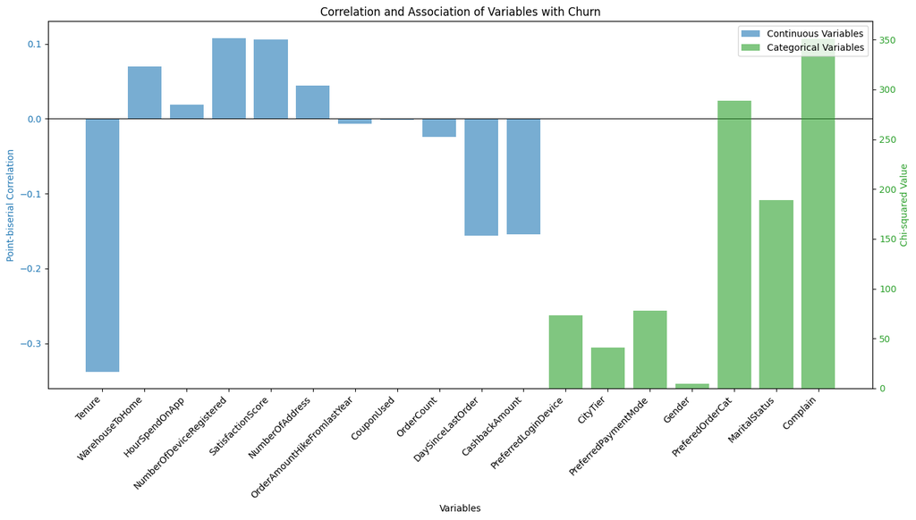

```python
import matplotlib.pyplot as plt
import seaborn as sns

# Separate continuous and categorical variables
continuous_corr = {k: v for k, v in correlation_results.items() if abs(v) <= 1}  # Point-biserial correlation values
categorical_corr = {k: v for k, v in correlation_results.items() if v > 1}  # Chi-squared values

# Convert to DataFrame
continuous_df = pd.DataFrame.from_dict(continuous_corr, orient='index', columns=['Correlation'])
categorical_df = pd.DataFrame.from_dict(categorical_corr, orient='index', columns=['Chi-squared'])

# Set up the figure and axis
fig, ax1 = plt.subplots(figsize=(14, 8))

# Plot continuous variables
color = 'tab:blue'
ax1.set_xlabel('Variables')
ax1.set_ylabel('Point-biserial Correlation', color=color)
ax1.bar(continuous_df.index, continuous_df['Correlation'], color=color, alpha=0.6, label='Continuous Variables')
ax1.tick_params(axis='y', labelcolor=color)
plt.xticks(rotation=45, ha='right')

# Create a second y-axis for categorical variables
ax2 = ax1.twinx()
color = 'tab:green'
ax2.set_ylabel('Chi-squared Value', color=color)
ax2.bar(categorical_df.index, categorical_df['Chi-squared'], color=color, alpha=0.6, label='Categorical Variables')
ax2.tick_params(axis='y', labelcolor=color)

# Add a horizontal line at y=0 for the first axis
ax1.axhline(0, color='black', linewidth=0.8)

# Add legends
fig.legend(loc='upper right', bbox_to_anchor=(1, 1), bbox_transform=ax1.transAxes)

# Set plot title and layout
plt.title('Correlation and Association of Variables with Churn')
fig.tight_layout()

# Show the plot
plt.show()
```

From the correlation found between the variables, we could see that there is a high positive correlation between complain and churn. Which means as much as the customer complains, he leaves the company. It is crucial to analyze the sentiments of customers through the complain to identify what the customer is trying to say. By maintaining the level of grievance displayed by the customer, and its correlation with exiting of previous customers, we can identify if the customer aims to leave the company and can provide him with ample compensation to make him/her stay with the company.

```python
X = data.drop(columns=['CustomerID', 'Churn'])
y = data['Churn']
```

```python
X_train, X_test, y_train, y_test = train_test_split(X, y, test_size=0.2, random_state=42)
```

```python
pipeline = Pipeline([
    ('scaler', StandardScaler()),  # Normalize features
    ('classifier', RandomForestClassifier(class_weight={0: 1, 1: 10}, random_state=42))  # Emphasize the importance of 'Churn' class
])
```

```python
pipeline.fit(X_train, y_train)
```

```
Pipeline(steps=[('scaler', StandardScaler()),
                ('classifier',
                 RandomForestClassifier(class_weight={0: 1, 1: 10},
                                        random_state=42))])
```

```python
y_pred = pipeline.predict(X_test)
```

```python
print("Classification Report:\n", classification_report(y_test, y_pred))
print("Confusion Matrix:\n", confusion_matrix(y_test, y_pred))
```

```
Classification Report:
               precision    recall  f1-score   support

           0       0.97      1.00      0.99       941
           1       0.99      0.86      0.92       185

    accuracy                           0.98      1126
   macro avg       0.98      0.93      0.96      1126
weighted avg       0.98      0.98      0.98      1126

Confusion Matrix:
 [[940   1]
 [ 25 160]]
```

```python
import joblib

# Save the model to a file
model_filename = 'churn_prediction_model.joblib'
joblib.dump(pipeline, model_filename)
```

```
['churn_prediction_model.joblib']
```

This model can be used to find the attrition rate based on the values of the variables given in this dataset. To predict it based on the emotions of users, we have to analyze the sentiments of content of the complaints. For this, we could use the sentiment analysis model that is trained on reviews from customers. One such model is our sentiment analysis on social media content as we presented in sprint 2.